# GAM Part1

Murray Logan

26 September, 2022

# Preparations

Load the necessary libraries

```r
library(mgcv)      #for GAMs
library(broom)     #for tidy results
library(gratia)    #for GAM plots
library(DHARMa)    #for residual diagnostics
library(performance) #for residuals diagnostics
library(see)         #for plotting residuals
library(emmeans)   #for marginal means etc
library(MuMIn)     #for model selection and AICc
library(tidyverse) #for data wrangling
```

# Scenario

This is an entirely fabricated example (how embarrising). So here is a picture of some Red Grouse Chicks to compensate..

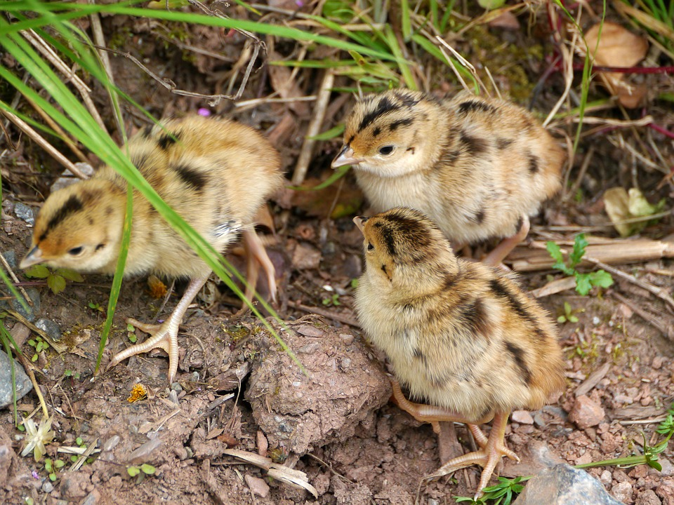

Red grouse chicks

Format of data.gp.csv data file

| x | y |
| --- | --- |
| 2 | 3 |
| 4 | 5 |
| 8 | 6 |
| 10 | 7 |
| 14 | 4 |

| **x** | - a continuous predictor |
| --- | --- |
| **y** | - a continuous response |

# Read in the data

```r
data_gam = read_csv('../public/data/data_gam.csv', trim_ws=TRUE)
glimpse(data_gam)
```

```
## Rows: 5
## Columns: 2
## $ x <dbl> 2, 4, 8, 10, 14
## $ y <dbl> 3, 5, 6, 7, 4
```

# Exploratory data analysis

Model formula:
$$y_i \sim{} \mathcal{N}(\mu_i, \sigma^2)\\
\mu_i =\beta_0 + f(x_i)\\
f(x_i) = \sum^k_{j=1}{b_j(x_i)\beta_j}$$

where $\beta_0$ is the y-intercept, and $f(x)$ indicates an additive smoothing function of $x$.

Although this is a ficticious example without a clear backstory, given that there are two continous predictors (and that one of these has been identified as a response and the other a predictor), we can assume that we might be interested in investigating the relationship between the two. As such, our typically starting point is to explore the basic trend between the two using a scatterplot.

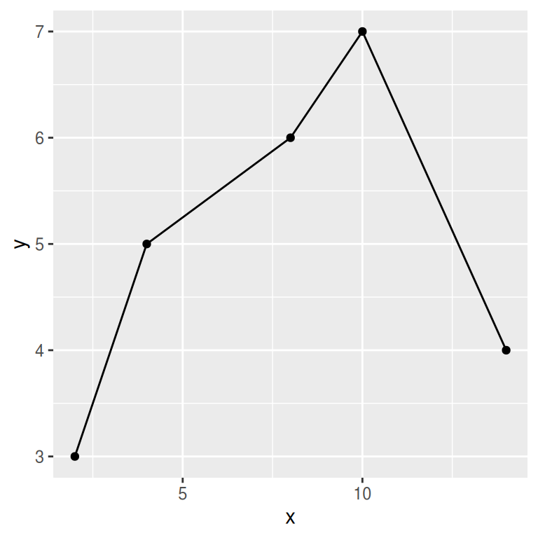

```r
ggplot(data_gam, aes(y=y, x=x))+
    geom_point()+
    geom_line()
```

This does not look like a particularly linear relationship. Lets fit a loess smoother..

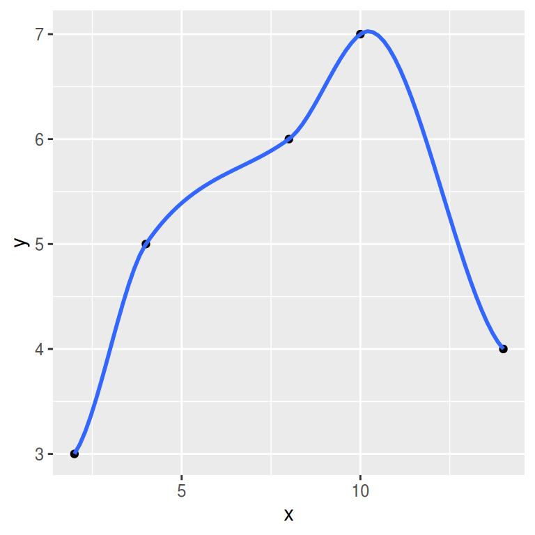

```r
ggplot(data_gam, aes(y=y, x=x))+
    geom_point()+
    geom_smooth()
```

And what would a linear smoother look like?

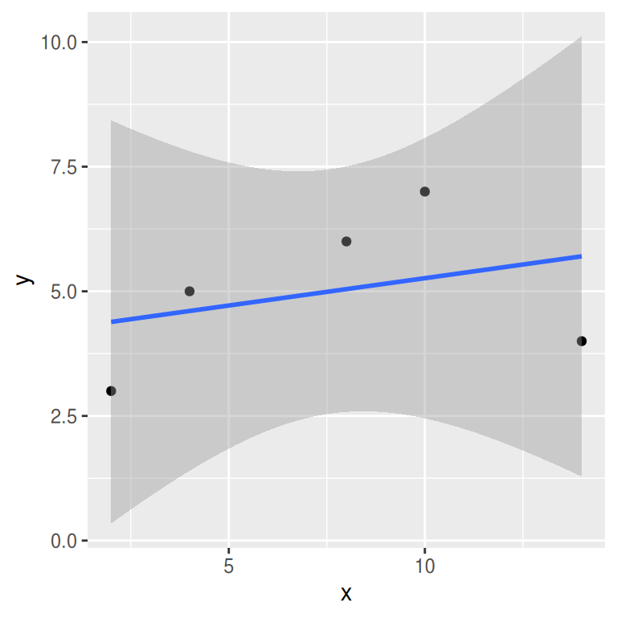

```r
ggplot(data_gam, aes(y=y, x=x))+
    geom_point()+
    geom_smooth(method='lm')
```

Rather than either a loess or linear smoother, we can also try a Generalized Additive Model (GAM) smoother. Dont pay too much attention to the GAM formula at this stage, this will be discussed later in the Model Fitting section.

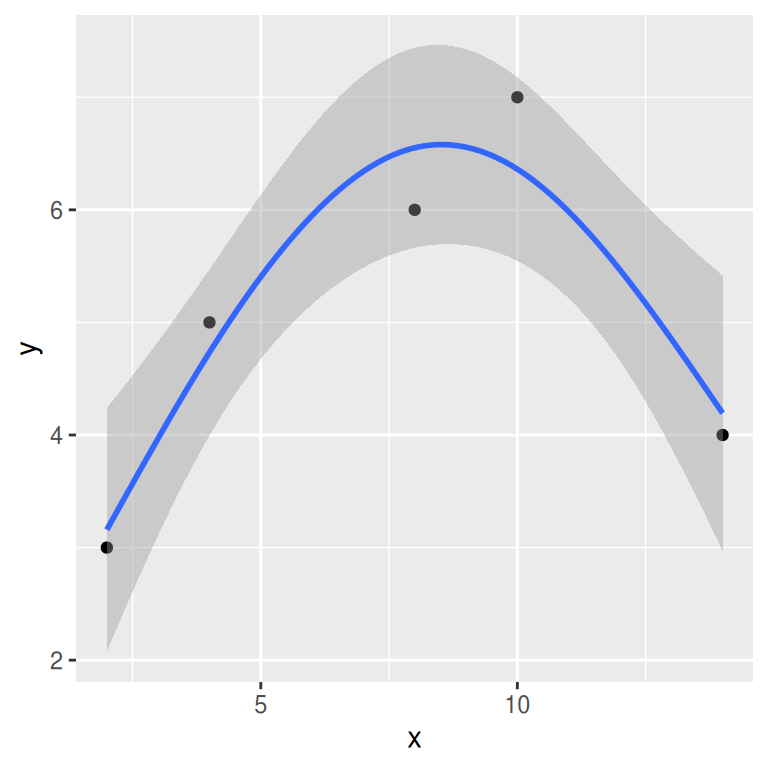

```r
ggplot(data_gam, aes(y=y, x=x))+
    geom_point()+
    geom_smooth(method='gam', formula=y~s(x,k=3))
```

**Conclusions:**

- it is clear that the relationship is not linear.
- it does appear that as x inreases, y initially increases before eventually declining again.
- we could model this with a polynomial, but for this exemple, we will use these data to illustrate the fitting of GAMs.

# Fit the model

Prior to fitting the GAM, it might be worth gaining a bit of an understanding of what will occur behind the scenes.

Lets say we intended to fit a smoother with three knots. The three knots equate to one at each end of the trend and one in the middle. We could reexpress our predictor (x) as three dummy variables that collectively reflect a spline (in this case, potentially two joined polynomials).

```r
data.frame(smoothCon(s(x, k=3),  data=data_gam)[[1]]$X) %>%
  bind_cols(data_gam)
```

| X1 | X2 | X3 | x | y |
| --- | --- | --- | --- | --- |
| 1.3554342 | 1 | -1.31122014 | 2 | 3 |
| 0.9289363 | 1 | -0.84292723 | 4 | 5 |
| 0.4755086 | 1 | 0.09365858 | 8 | 6 |
| 0.5780165 | 1 | 0.56195149 | 10 | 7 |
| 1.3189632 | 1 | 1.49853730 | 14 | 4 |

And we could visualize these dummies as three separate components.

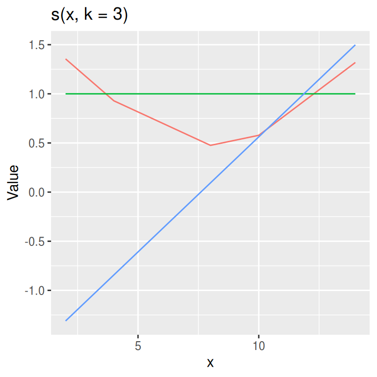

```r
basis(s(x, k=3),  data=data_gam) %>% draw
```

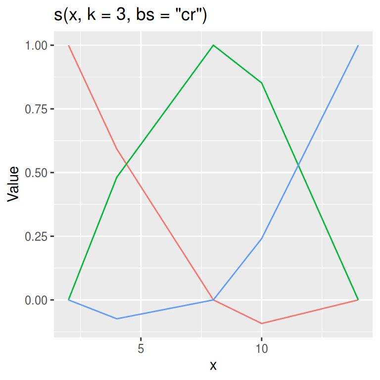

```r
basis(s(x, k=3, bs='cr'),  data=data_gam) %>% draw
```

OR

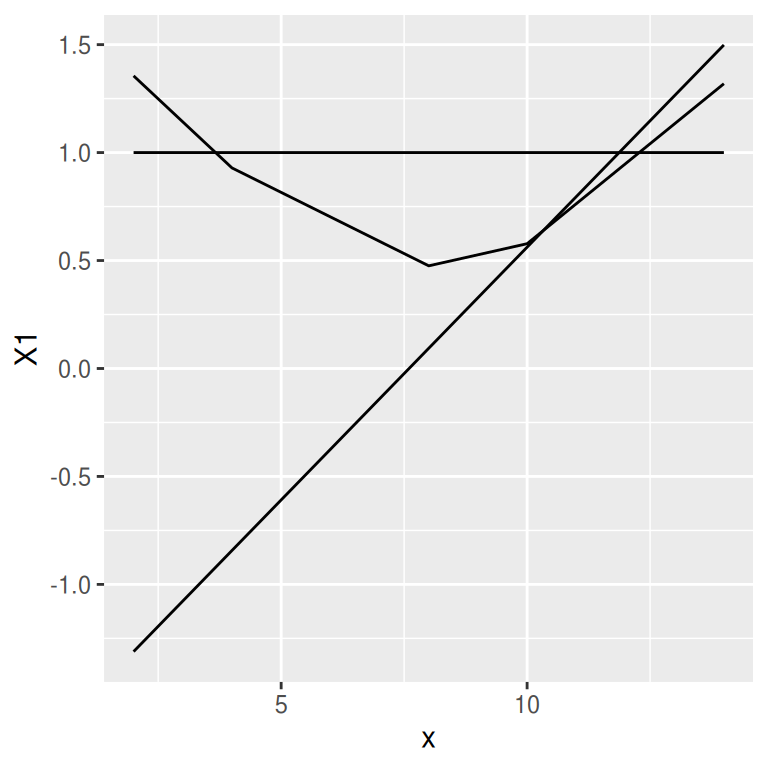

```r
newdata <-
    data.frame(smoothCon(s(x, k=3),  data=data_gam)[[1]]$X) %>%
    bind_cols(data_gam)
ggplot(newdata,  aes(x=x)) +
    geom_line(aes(y=X1)) +
    geom_line(aes(y=X2)) +
    geom_line(aes(y=X3))
```

So with that in mind, lets fit the GAM.

```r
data_gam.gam <- gam(y~s(x), data = data_gam, method = 'REML')
```

```
## Error in smooth.construct.tp.smooth.spec(object, dk$data, dk$knots): A term has fewer unique covariate combinations than specified maximum degrees of freedom
```

**Conclusions:**

- this error indicates that there is not enough data to fit the starting number of knots (10) attempted.
- in order to fit a GAM, we will need to reduce the maximum number of knots. We will set this to 3 and try fitting again.

We will optimise the degree of smoothing via REML.

```r
data_gam.gam <- gam(y~s(x, k = 3), data=data_gam, method = 'REML')
#data.gp.gam <- gam(y~s(x,k=3, bs='cr'), data=data.gp, method=)
#data.gp.gam <- gam(y~s(x,k=3, bs='ps'), data=data.gp)
```

# Model validation

## gam.check

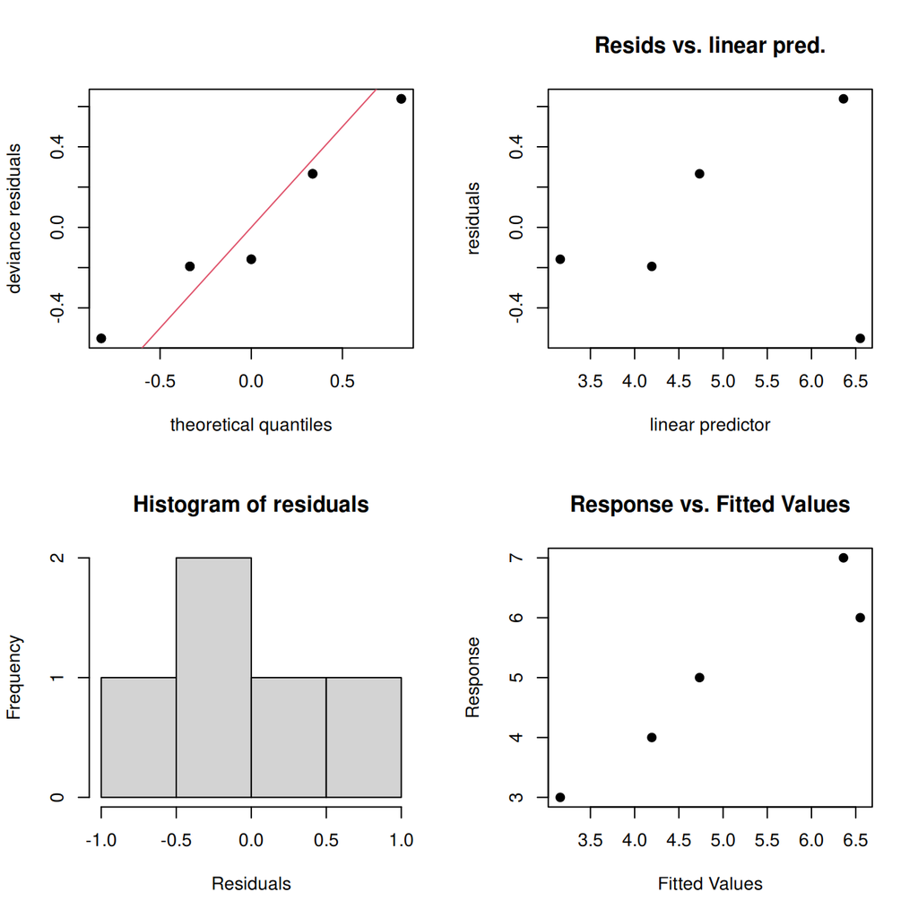

```
##
## Method: REML   Optimizer: outer newton
## full convergence after 5 iterations.
## Gradient range [-4.151024e-06,2.176788e-06]
## (score 6.024247 & scale 0.4120262).
## Hessian positive definite, eigenvalue range [0.2676093,1.6827].
## Model rank =  3 / 3
##
## Basis dimension (k) checking results. Low p-value (k-index<1) may
## indicate that k is too low, especially if edf is close to k'.
##
##        k'  edf k-index p-value
## s(x) 2.00 1.95    2.19    0.98
```

```r
gam.check(data_gam.gam, pch = 19)
```

**Conclusions:**

- the outputs provide diagnostics. GAMS tend to be more sensitive to distributional assumptions than regular GLM. Furthermore, it is important to test whether the basis dimensions (a max of k in this case) is too small - this could lead to oversmoothing.
- starting with the graphical outputs:
  - the top left figure illustrates a Q-Q like plot. We are looking to see that the points fall along the straight diagonal line. In this case, it is not fantastic, yet this analysis is based on only a very small amount of data.
  - the top right figure is a residual plot. As always, we want this to be random noise. Again given the small sample size here, little can be said.
  - the bottom left figure is a density distribution of the residuals. This should follow a normal distribution - and kind of does.
  - the bottom right figure is a plot of the observed values against the fitted values. Ideally, this should be a straight line. The tighter the cloud of points, the better the model is able to recreate the training data.
- now for the terminal outputs:
  - k’ (2.00) indicates the number of knots minus 1 (=degrees of freedom).
  - edf (1.95) indicates the estimated degrees of freedom. This is the optimized degrees of freedom (number of knots) after penalizing for complexity. The penalizing is why the estimated degrees of freedom is not an integer.
  - the k-index (2.19) is calculated as the difference in residuals (for values that are near neighbours) divided by the residual variance. The smaller the k-index is below 1, the more likely it is that there is a missed pattern and the model is oversmoothed.
  - the p-value, which is calculated by randomly re-shuffling the residuals and repeatedly calculating the k-index, provides a test for whether the basis dimension (k) has been set too low.
  - if the p-value is low and k-index is less than 1 (especially is edf is close to k’), it suggests that k has been set too low. This is not that case here.
  - if the above test had suggested that k was too low, it is generally recommended that you double k and re-fit the model.

## k.check

The `k.check()` function provides a more targetted summary of the `gam.check()` output.

```r
k.check(data_gam.gam)
```

```
##      k'      edf  k-index p-value
## s(x)  2 1.949003 2.186796  0.9925
```

**Conclusions:**

- see the conclusions from gam.check above.

## appraise

The `appraise()` function provides the graphical diagnostics in `ggplot`.

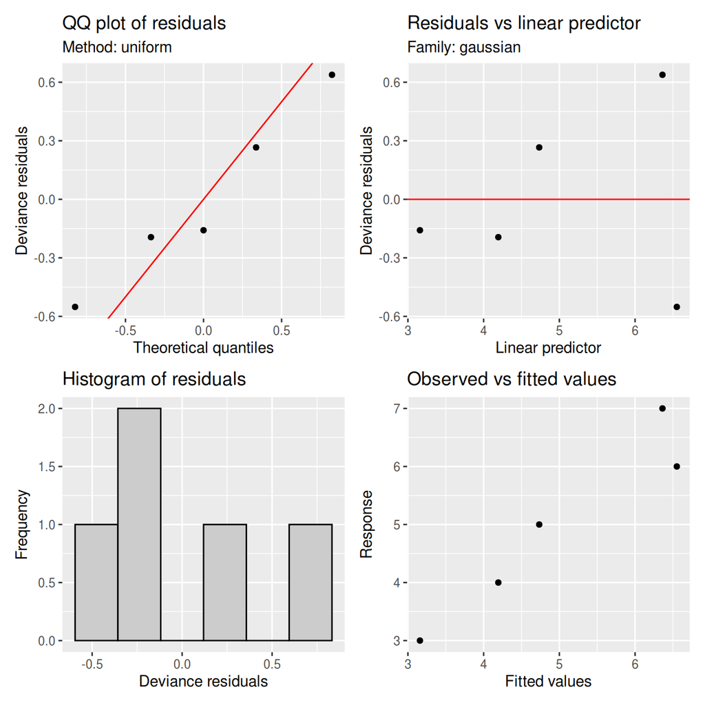

```r
appraise(data_gam.gam)
```

**Conclusions:**

- see the conclusions from gam.check above.

## check_model

```r
performance::check_model(data_gam.gam)
```

```
## Error in d[, !(names(data) %in% all.varying), drop = FALSE]: incorrect number of dimensions
```

**Conclusions:**

## check_distribution

The `check_distribution()` function attempts to provided some guidance as to which distributions are likely to be useful for modelling the response. Note, this is very much only experimental and not going to be all that useful for a small sample size.

```r
performance::check_distribution(data_gam.gam)
```

| Distribution | p_Residuals | p_Response |
| --- | --- | --- |
| bernoulli | 0.03125 | 0.00000 |
| beta | 0.31250 | 0.00000 |
| beta-binomial | 0.00000 | 0.21875 |
| binomial | 0.03125 | 0.40625 |
| chi | 0.03125 | 0.00000 |
| exponential | 0.09375 | 0.00000 |
| F | 0.00000 | 0.00000 |
| gamma | 0.00000 | 0.03125 |
| lognormal | 0.00000 | 0.00000 |
| neg. binomial (zero-infl.) | 0.00000 | 0.00000 |

[output cut: 8 more lines]

**Conclusions:**

## DHARMa residuals

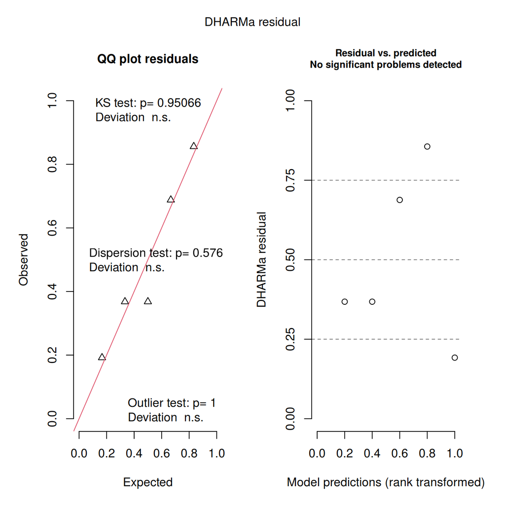

```r
resids <- DHARMa::simulateResiduals(data_gam.gam,  plot=TRUE)
```

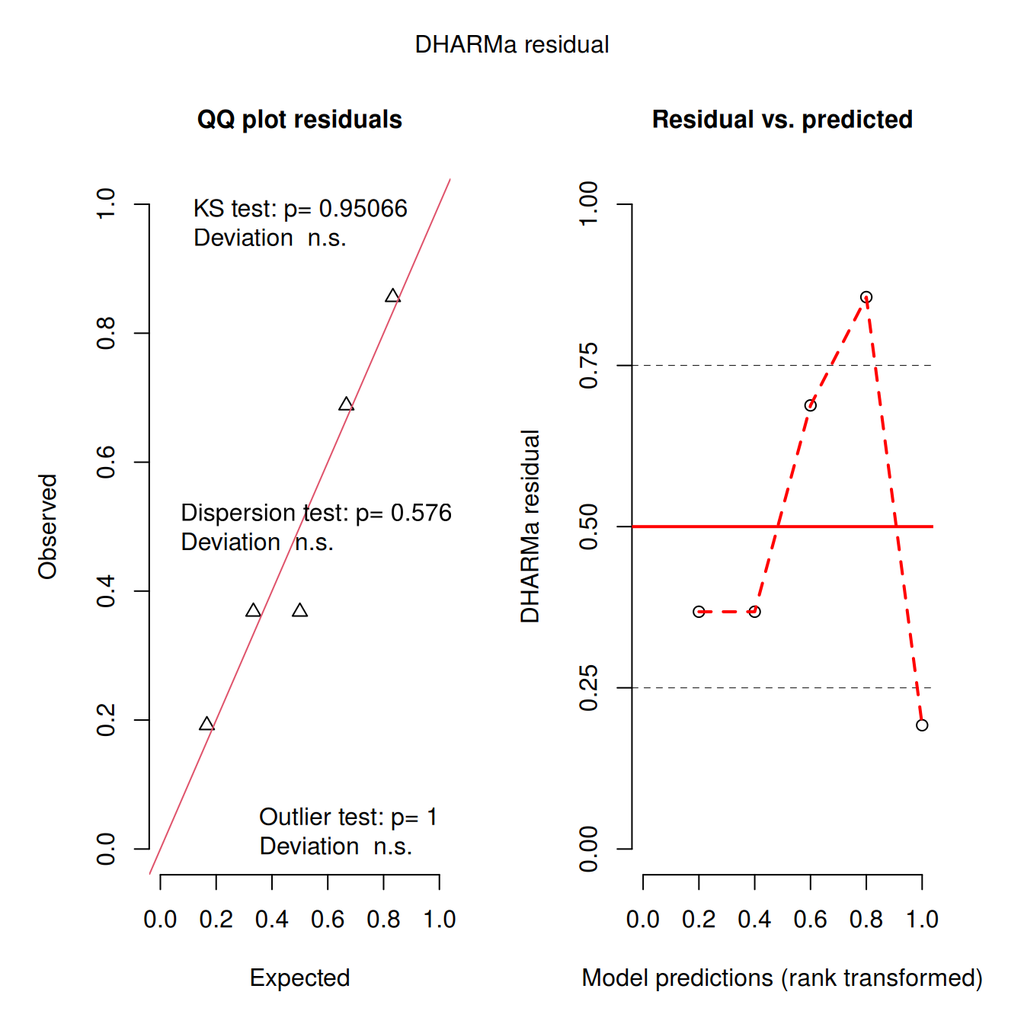

```r
##OR in this case, it would be better to plot separately
##since there are not enough observations for the quantile regressions
##and it struggles and tries for a while
resids <- DHARMa::simulateResiduals(data_gam.gam)
plot(resids, quantreg = FALSE)
```

**Conclusions:**

- DHARMa residuals do not suggest anything alarming.

## Concurvity

Concurvity is the non-linear equivalent of (multi)collinerity. Concurvity measures how well each smooth could be approximated by either a combination of the other smooth(s) or each individual other smooth. Three metrics are generated - all of which are bounded between 0 (no issue) and 1 (total lack of indentifiability) Essentially, we can decompose a smooth term into the component that lies within the space (g) of other terms and the component that is unique to the terms own space (f). The three metrics are all variants on the ratio of g:f

- worst - largest ratio possible from any estimated coefficients (data ignored) - worst case scenario
- observed - ratio based on observed coefficients - can be over optimistic
- estimate - a measure of the extent to which f basis can be explained by g basis. It is a good compromise between over optimism and over pessimism, yet is harder to understand

```r
concurvity(data_gam.gam)
```

```
##          para         s(x)
## worst       0 9.999514e-33
## observed    0 6.227113e-34
## estimate    0 9.207256e-33
```

```r
concurvity(data_gam.gam, full=FALSE)
```

```
## $worst
##      para         s(x)
## para    1 9.999514e-33
## s(x)    0 1.000000e+00
##
## $observed
##      para         s(x)
## para    1 6.227113e-34
## s(x)    0 1.000000e+00
##
## $estimate
##      para         s(x)
## para    1 9.207256e-33
## s(x)    0 1.000000e+00
```

**Conclusions:**

- the above was only included so as to get used to the range of diagnostics that should become routine when fitting GAMs. Of course, since in this case, there is only a single smooth, concurvity cannot be an issue.

# Partial plots

There are fewer options for plotting partial plots from GAM. Note, the plots are passed on to cowplot for multiple figures and thus it is not possible to use + to add more ggplot instructions.

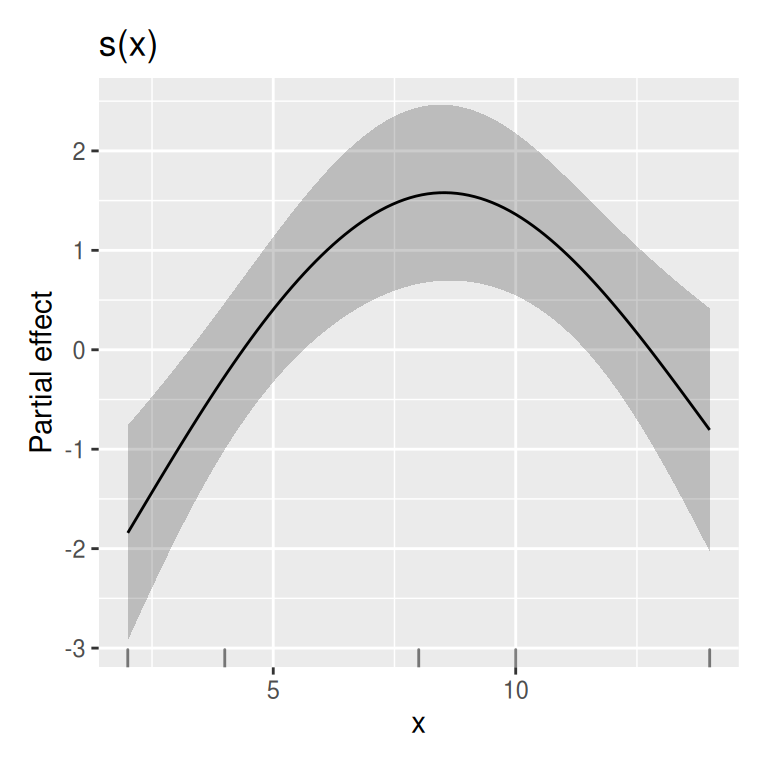

```r
draw(data_gam.gam)
```

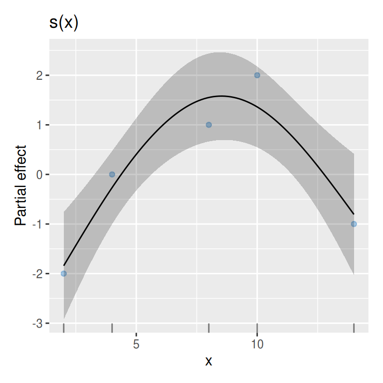

```r
## or with the 'partial residuals' (quasi observations) included
draw(data_gam.gam, residuals=TRUE)
```

# Model investigation / hypothesis testing

## summary

```r
summary(data_gam.gam)
```

```
##
## Family: gaussian
## Link function: identity
##
## Formula:
## y ~ s(x, k = 3)
##
## Parametric coefficients:
##             Estimate Std. Error t value Pr(>|t|)
## (Intercept)   5.0000     0.2871   17.42  0.00293 **
## ---
## Signif. codes:  0 '***' 0.001 '**' 0.01 '*' 0.05 '.' 0.1 ' ' 1
##
## Approximate significance of smooth terms:
##        edf Ref.df     F p-value
## s(x) 1.949  1.997 10.88  0.0861 .
## ---
## Signif. codes:  0 '***' 0.001 '**' 0.01 '*' 0.05 '.' 0.1 ' ' 1
##
## R-sq.(adj) =  0.835   Deviance explained = 91.5%
## -REML = 6.0242  Scale est. = 0.41203   n = 5
```

**Conclusions:**

## tidy

```r
tidy(data_gam.gam)
```

| term | edf | ref.df | statistic | p.value |
| --- | --- | --- | --- | --- |
| s(x) | 1.949003 | 1.997399 | 10.87853 | 0.08606014 |

## AIC

```r
AIC(data_gam.gam)
```

```
## [1] 13.29528
```

```r
AICc(data_gam.gam)
```

```
## [1] 15375.87
```

# Further analyses

For the purpose of further illustration, lets proceed as if the above analyses had suggested a significantly wiggly relationship. If this was the case, in addition to a qualitative description of the trend (for example, that the response intially increases to a peak before declining again), we might want to be able to provide estimates about:

- the value of x associated with the peak (or trough is that was appropriate). Such values correspond to locations along the trend where the slope is equal to zero.
- the value(s) of x associated with the greatest rate of change in the response. Such values correspond to locations along the trend where the slope is of greatest magnitude.
- the value(s) of x associated with the greatest change in trajectory. Such values might help identify underlying the onset of pertebations and correspond to locations along the trend with teh greatest degree of curvature.

If we had a formula for the curve, we could simply take the first order derivatives to find the slope (addressing the first two of the above) and the second order derivatives (to address the third of the above). Unfortunately, we do not have such an equation. However, it is possible to estimate these derivatives via finite differences. This is a technique in which predictions are made for a large sequence of values of a predictor (hence very small interval between predictions), and the instantaneous slopes are calculated between successive pairs of predictions.

## find the optimum

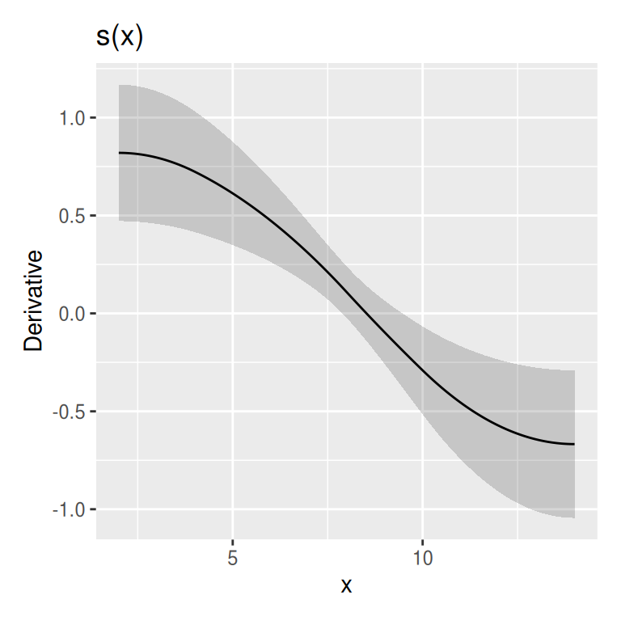

```r
derivatives(data_gam.gam,  order=1) %>% draw
```

```r
## Find the approximate peak
d = derivatives(data_gam.gam,  order=1)
d
```

| smooth | var | data | derivative | se | crit | lower | upper |
| --- | --- | --- | --- | --- | --- | --- | --- |
| s(x) | x | 2.000000 | 0.819792241 | 0.17781359 | 1.959964 | 0.471284000 | 1.168300482 |
| s(x) | x | 2.060302 | 0.819704702 | 0.17779481 | 1.959964 | 0.471233282 | 1.168176122 |
| s(x) | x | 2.120603 | 0.819442225 | 0.17773848 | 1.959964 | 0.471081207 | 1.167803243 |
| s(x) | x | 2.180905 | 0.819004558 | 0.17764456 | 1.959964 | 0.470827617 | 1.167181500 |
| s(x) | x | 2.241206 | 0.818391943 | 0.17751311 | 1.959964 | 0.470472631 | 1.166311255 |
| s(x) | x | 2.301508 | 0.817604270 | 0.17734413 | 1.959964 | 0.470016160 | 1.165192381 |
| s(x) | x | 2.361809 | 0.816641539 | 0.17713763 | 1.959964 | 0.469458167 | 1.163824910 |
| s(x) | x | 2.422111 | 0.815503840 | 0.17689365 | 1.959964 | 0.468798662 | 1.162209018 |
| s(x) | x | 2.482412 | 0.814191012 | 0.17661218 | 1.959964 | 0.468037500 | 1.160344525 |
| s(x) | x | 2.542714 | 0.812703206 | 0.17629329 | 1.959964 | 0.467174706 | 1.158231705 |

[output cut: 190 more lines]

```r
d %>% summarise(Value=data[which.min(abs(derivative))],
                lower=data[which.min(abs(lower))],
                upper=data[which.min(abs(upper))])
```

| Value | lower | upper |
| --- | --- | --- |
| 8.512563 | 7.909548 | 9.477387 |

**Conclusions:**

- the optimum in the trend was found to be associated with an estimated predictor value of 8.51.
- the 95% confidence interval for the value of the predictor associated with the optimum is 7.91-9.48.
- if there were more than one peak or trough, we could estimate multiples simply by restricting the search range for each estimate.

## find the largest slope

If we wanted to find the value of the predictor that corresponded to the steepest positive slope:

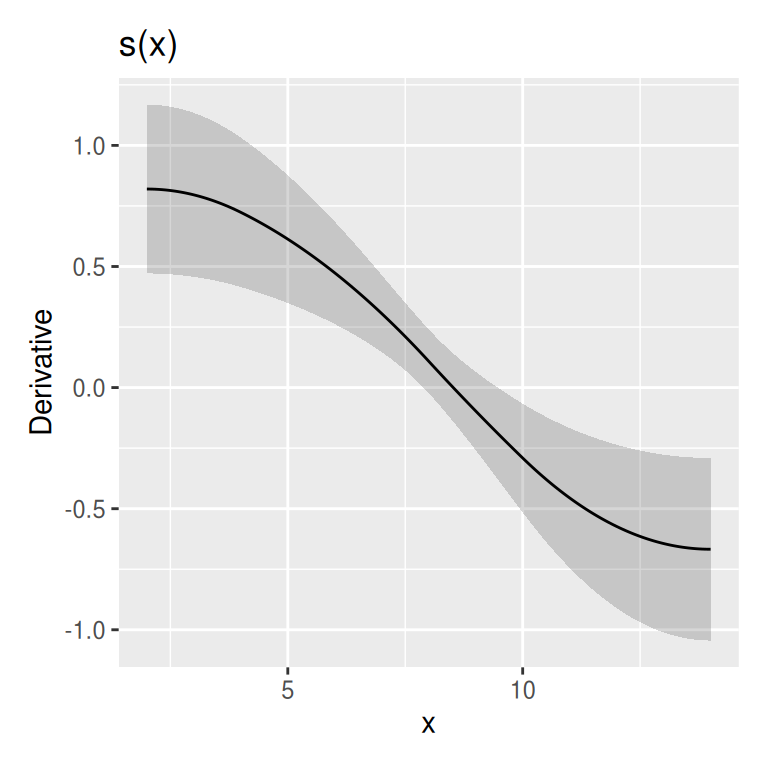

```r
derivatives(data_gam.gam,  order=1) %>% draw
```

```r
## Find the approximate peak
d = derivatives(data_gam.gam,  order=1)
d
```

| smooth | var | data | derivative | se | crit | lower | upper |
| --- | --- | --- | --- | --- | --- | --- | --- |
| s(x) | x | 2.000000 | 0.819792241 | 0.17781359 | 1.959964 | 0.471284000 | 1.168300482 |
| s(x) | x | 2.060302 | 0.819704702 | 0.17779481 | 1.959964 | 0.471233282 | 1.168176122 |
| s(x) | x | 2.120603 | 0.819442225 | 0.17773848 | 1.959964 | 0.471081207 | 1.167803243 |
| s(x) | x | 2.180905 | 0.819004558 | 0.17764456 | 1.959964 | 0.470827617 | 1.167181500 |
| s(x) | x | 2.241206 | 0.818391943 | 0.17751311 | 1.959964 | 0.470472631 | 1.166311255 |
| s(x) | x | 2.301508 | 0.817604270 | 0.17734413 | 1.959964 | 0.470016160 | 1.165192381 |
| s(x) | x | 2.361809 | 0.816641539 | 0.17713763 | 1.959964 | 0.469458167 | 1.163824910 |
| s(x) | x | 2.422111 | 0.815503840 | 0.17689365 | 1.959964 | 0.468798662 | 1.162209018 |
| s(x) | x | 2.482412 | 0.814191012 | 0.17661218 | 1.959964 | 0.468037500 | 1.160344525 |
| s(x) | x | 2.542714 | 0.812703206 | 0.17629329 | 1.959964 | 0.467174706 | 1.158231705 |

[output cut: 190 more lines]

```r
d %>% summarise(
        maxDer = max(derivative),
        Value=data[which.max(derivative)],
        lower=data[which.min(abs(maxDer-lower))],
        upper=data[which.min(abs(maxDer-upper))])
```

| maxDer | Value | lower | upper |
| --- | --- | --- | --- |
| 0.8197922 | 2 | 2 | 5.316583 |

**Conclusions:**

- the steepest positive slope in the trend was found to be associated with an estimated predictor value of 2.
- the 95% confidence interval for the value of the predictor associated with the optimum is 2-5.32.
- note, a similar routine could be performed to provide the steepest negative slope. Similiarly, by restricting the search range, localised steepest slopes could be estimated.

## find the greatest change in curvature

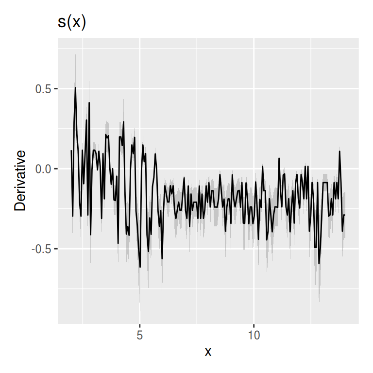

```r
derivatives(data_gam.gam,  order=2) %>% draw
```

```r
## Find the approximate peak
d = derivatives(data_gam.gam,  order=2)
d
```

| smooth | var | data | derivative | se | crit | lower | upper |
| --- | --- | --- | --- | --- | --- | --- | --- |
| s(x) | x | 2.000000 | 0.115689990 | 0.025424559 | 1.959964 | 0.065858769 | 0.1655212101 |
| s(x) | x | 2.060302 | -0.296524816 | 0.071433648 | 1.959964 | -0.436532194 | -0.1565174386 |
| s(x) | x | 2.120603 | 0.289304080 | 0.073006904 | 1.959964 | 0.146213177 | 0.4323949837 |
| s(x) | x | 2.180905 | 0.506242588 | 0.117353538 | 1.959964 | 0.276233880 | 0.7362512955 |
| s(x) | x | 2.241206 | 0.216938507 | 0.047221593 | 1.959964 | 0.124385886 | 0.3094911282 |
| s(x) | x | 2.301508 | 0.108469254 | 0.023610796 | 1.959964 | 0.062192943 | 0.1547455641 |
| s(x) | x | 2.361809 | -0.209717771 | 0.046642429 | 1.959964 | -0.301135252 | -0.1183002903 |
| s(x) | x | 2.422111 | -0.296524816 | 0.071433648 | 1.959964 | -0.436532194 | -0.1565174386 |
| s(x) | x | 2.482412 | 0.115689990 | 0.025424559 | 1.959964 | 0.065858769 | 0.1655212101 |
| s(x) | x | 2.542714 | -0.094027781 | 0.025032408 | 1.959964 | -0.143090399 | -0.0449651635 |

[output cut: 190 more lines]

```r
d %>% summarise(Value=data[which.max(abs(derivative))],
                lower=data[which.max(abs(lower))],
                upper=data[which.max(abs(upper))])
```

| Value | lower | upper |
| --- | --- | --- |
| 5.015075 | 5.015075 | 2.180905 |

**Conclusions:**

- this has seemingly not yielded overly useful results in this case

# Summary figures

Although it is possible to obtain partial plots using variety of methods (see above), all of these produce partial plots that are centered on the y-axis. Whist this is technically correct, as the GAM partial plot is concerned with describing the shape of the trend rather than the absolute value along the trend and it is not burdened with having to account for the impacts of other predictors on the absolute values, it does make it less useful as a visual representation of the nature of the relationship between the response and predictor(s).

So an alternate way to produce a useful summary figure is to base the figure on predictions (using `emmeans()` for convenience).

```r
data_gam.list <- with(data_gam, list(x = modelr::seq_range(x, n = 100)))

newdata = emmeans(data_gam.gam, ~x, at = data_gam.list) %>%
    as.data.frame
head(newdata)
```

|  | x | emmean | SE | df | lower.CL | upper.CL |
| --- | --- | --- | --- | --- | --- | --- |
| 1 | 2.000000 | 3.158610 | 0.5522989 | 2.050997 | 0.8379937 | 5.479227 |
| 2 | 2.121212 | 3.257965 | 0.5366681 | 2.050997 | 1.0030250 | 5.512905 |
| 3 | 2.242424 | 3.357234 | 0.5214687 | 2.050997 | 1.1661572 | 5.548310 |
| 4 | 2.363636 | 3.456331 | 0.5067463 | 2.050997 | 1.3271145 | 5.585547 |
| 5 | 2.484848 | 3.555171 | 0.4925469 | 2.050997 | 1.4856168 | 5.624725 |
| 6 | 2.606061 | 3.653668 | 0.4789174 | 2.050997 | 1.6413817 | 5.665955 |

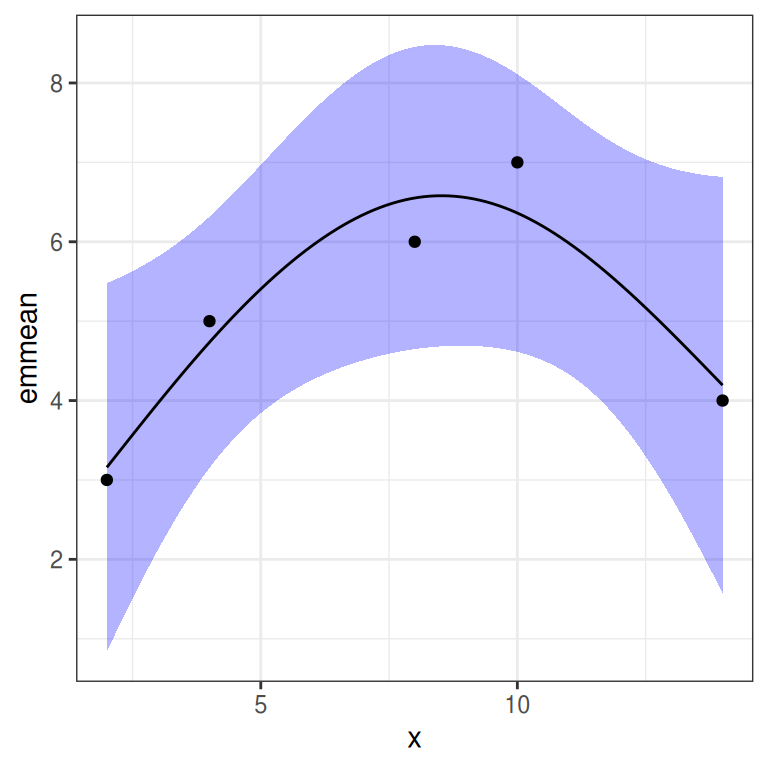

```r
ggplot(newdata, aes(y=emmean, x=x)) +
    geom_ribbon(aes(ymin=lower.CL, ymax=upper.CL), fill='blue', alpha=0.3) +
    geom_line() +
    geom_point(data=data_gam, aes(y=y,x=x))+
    theme_bw()
```

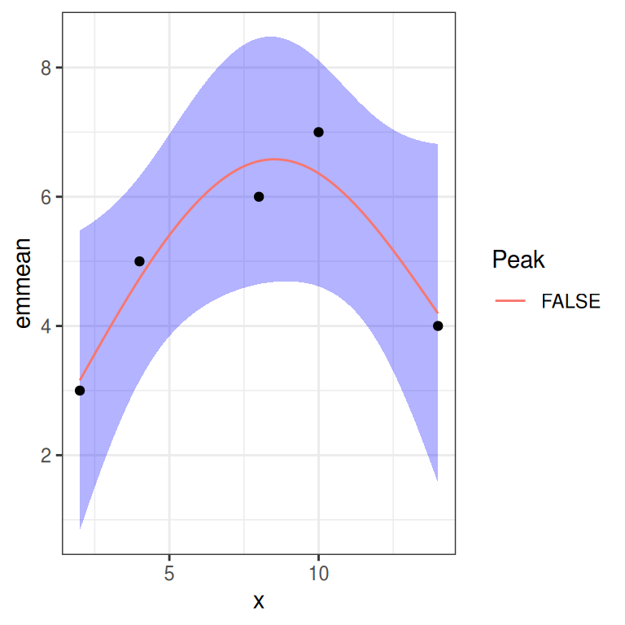

```r
newdata <- newdata %>% mutate(Peak = between(emmean, 7.91, 9.48))
ggplot(newdata, aes(y=emmean, x=x)) +
    geom_ribbon(aes(ymin=lower.CL, ymax=upper.CL), fill='blue', alpha=0.3) +
    geom_line(aes(color=Peak)) +
    geom_point(data=data_gam, aes(y=y,x=x))+
    theme_bw()
```

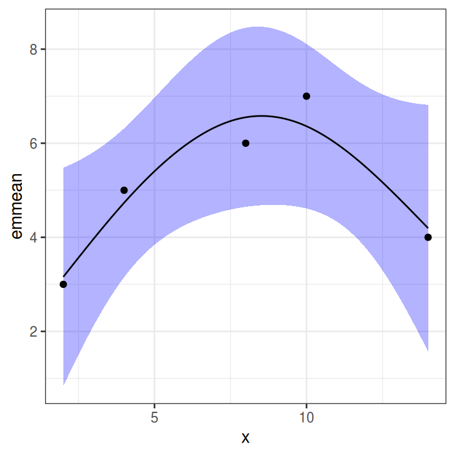

```r
## Partials
#resid.list = list(x=data_gam$x)
newdata.partial = data_gam %>%
  mutate(Pred = predict(data_gam.gam,  type='link'),
         Res = resid(data_gam.gam),
         Resid = Pred + Res)
#newdata.partial = emmeans(data_gam.gam, ~x, at=resid.list) %>%
#    as.data.frame %>%
#    mutate(Resid = emmean + resid(data_gam.gam))

ggplot(newdata, aes(y=emmean, x=x)) +
    geom_ribbon(aes(ymin=lower.CL, ymax=upper.CL), fill='blue', alpha=0.3) +
    geom_line() +
    geom_point(data=newdata.partial, aes(y=Resid,x=x))+
    theme_bw()
```

# References